# Anova - ćw5

Paulina Dziwak

- Prosta (=jednoczynnikowa) analiza wariancji (ANOVA)
- Nieparametryczna alternatywa - ANOVA na rangach (test Kruskala-Wallisa)

Potrzebne pakiety:

- tidyverse, ggplot2 (już używane)
- nortest (zawierające testy na normalność rozkładu)
- ggpubr (ułatwiające tworzenie pewnych wykresów)

Potrzebne funkcje:

Funkcje do tworzenia wykresów: * hist() – tworzy histogramy (do eksploracyjnej analizy danych sprawdzenia kształtu rozkładu itp.). * ggplot() –z wykorzystaniem opcji „stat_summary()” i własną funkcją Mean_SE_95CI (wprowadzone w poprzednich zajęciach).

Funkcje do wykonywania analiz i testów statystycznych:

- summary(), summarize() – do przedstawienia statystyk opisowych
- shapiro.test() – do sprawdzania **normalności rozkładu**
- aov() - standardowa funkcja R do wykonania **analizy wariancji**. Wywołanie: Model_output <- aov(Y ~ Group, data = My_data) gdzie Y to ilościowa zmienna zależna, Group to czynnik kategoryczny (zmienna grupująca).

Wynikowy obiekt przedstawia na wydruku tylko dane podstawowe do analizy wariancje, ale obiekt ten zawiera dane, na podstawie których generowane są pełne wyniki:

- summary(Model_output) – produkuje typową „tabelę ANOVA” z testem istotności;
- TukeyHSD(Model_output) – test post hoc (= a posteriori) dla porównań między wszystkimi parami grup.
- plot(Model_output, Liczba) – tworzy różne wykresy, przy czym Liczba (1-5) wskazuje na rodzaj generowanego wykresu.

Szczególnie użyteczne są trzy wykresy:

- 1 - wykres residuals vs predicted (wartości resztowe vs. wartości przewidywane). Pozwala na „optyczner” sprawdzenie czy wariancja reszt jest podobna dla grup, a także czy rozkład reszt jest symetryczny;
- 2 - Quantile plot (reszty standaryzowane vs kwantyle teoretyczne dla rozkładu normalnego) – do sprawdzenia czy rozkład jest normalny; jeśli tak, punkty leżą mniej więcej na prostej (logika tego wykresu jest podobna do logiki w teście Shapiro-Wilka);
- 4 - Cook’s distance (D): miara wielkości wpływu pojedynczej obserwacji na wyniki; dystans Cooka łączy informacje o wielkości wartości resztowej i tzw. „dźwigni” (leverage), która informuje o tym jak wartość predyktora dla danej obserwacji odbiega od średniej wartości predyktora. Dystans Cooka D jest więc szczególne użyteczny w bardziej zaawansowanych modelach, w których występują też predyktory ilościowe (na dalszych zajęciach), a w przypadku modeli ANOVA dostarczają informacji podobnej jak wartości resztowe, ale w zmodyfikowanej skali. Jeśli wartość D jest większa niż 1, to powinna być traktowana jako „podejrzana”, bo nie tylko odbiega od typowych, ale fakt ten ma znaczny wpływ na konkluzje.
- hist(Model_output$residuals) – przedstawia histogramy rozkładu reszt.

Wartości resztowe to różnice między wartościami rzeczywistymi a wartościami przewidywanymi przez model statystyczny. Wartości resztowe są ważne, ponieważ pozwalają nam ocenić jakość dopasowania modelu do danych. Idealnie dopasowany model powinien mieć wartości resztowe bliskie zeru, co oznacza, że model jest w stanie wytłumaczyć większość zmienności w danych. Jeśli wartości resztowe są duże, może to sugerować, że model nie jest odpowiedni dla danych i konieczna jest dalsza analiza.

W R wartości resztowe można obliczyć dla modeli statystycznych za pomocą funkcji residuals() na przykład, po oszacowaniu modelu regresji liniowej przy użyciu funkcji lm().

Nieparametryczna alternatywa dla prostej analizy wariancji: test Kruskala-Wallisa, wywoływany podobnie jak aov():

- kruskal.test(Y ~ Group, data = My_data) Test Kruskala-Wallisa, działa tak samo jak test Wilcoxona, ale może być zastosowany do więcej niż dwóch grup. Jest równoważny wykonaniu prostej analizy wariancji na danych zamienionych na rangi (czyli przetworzonych do skali porządkowej). Dane „surowe” można zamienić na rangi funkcją rank() i potem wykonać aov() na rangach – wynik będzie taki sam.

```r
library(tidyverse)
```

```r
library(ggplot2)
library(nortest)
library(ggpubr)
library(outliers)
```

# Zadanie 1

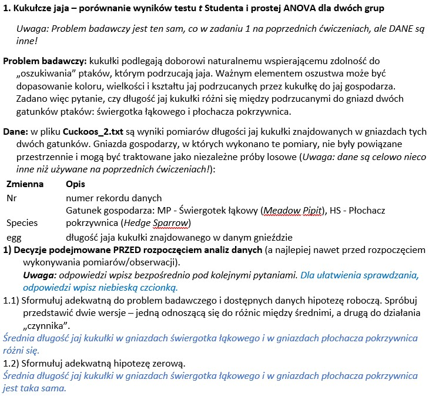

1.3) Sformułuj adekwatną hipotezę alternatywną. Średnia długość jaj kukułki w gniazdach świergotka łąkowego i w gniazdach płochacza pokrzywnica różni się.

1.4) Jakiego testu użyjesz „z wyboru” do testowania hipotezy zerowej? test t-Studenta dla prób niezależnych lub test wariancji

1.5. Jakie założenia teoretycznie dotyczące rozkładu są wymagane dla wybranego testu?

- rozkład zbliżony do rozkładu normalnego
- próby niezależne
- równe wariancje
2. Analizy statystyczne  
   Uwaga: w odpowiedziach umieść zarówno kod R jak i wyniki jego wykonania.

2.1) Przedstaw adekwatne dla tego projektu statystyki opisowe. Na potrzeby tych ćwiczeń przedstaw je w postaci wartości liczbowych jak i w postaci graficznej.

```r
Cuckoos_2 <- read.table("Cuckoos_2.txt", header = TRUE, sep = "\t")
Cuckoos_2
```

```
##    Nr Species  EggL
## 1   1      HS 21.65
## 2   2      HS 23.85
## 3   3      HS 23.05
## 4   4      HS 23.05
## 5   5      HS 24.05
## 6   6      HS 25.05
## 7   7      HS 23.05
## 8   8      HS 23.85
## 9   9      HS 22.85
## 10 10      HS 22.05
## 11 11      HS 20.85
## 12 12      HS 23.05
## 13 13      HS 23.45
## 14 14      HS 23.85
## 15 15      MP 21.85
## 16 16      MP 22.05
## 17 17      MP 20.05
## 18 18      MP 21.65
## 19 19      MP 22.05
## 20 20      MP 22.45
## 21 21      MP 19.65
## 22 22      MP 22.05
## 23 23      MP 22.25
## 24 24      MP 22.45
## 25 25      MP 22.05
## 26 26      MP 21.85
## 27 27      MP 22.25
## 28 28      MP 22.05
```

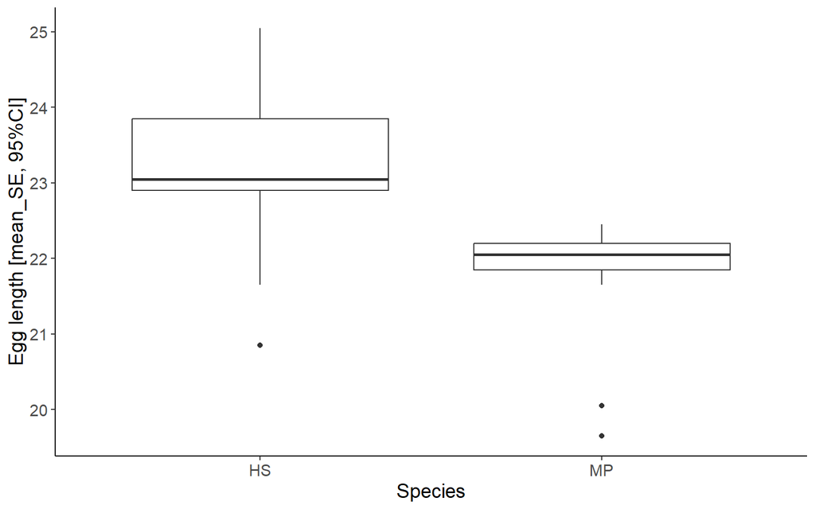

```r
#2.1
ggplot(data = Cuckoos_2, mapping = aes(x = Species,
                                       y = EggL)) + geom_boxplot() +
  theme_classic() + theme(text = element_text(size = 14)) +
  labs(x = "Species", y = "Egg length [mean_SE, 95%CI]")
```

```r
summary(subset(Cuckoos_2, Species=="MP")$EggL)
```

```
##    Min. 1st Qu.  Median    Mean 3rd Qu.    Max.
##   19.65   21.85   22.05   21.76   22.20   22.45
```

```r
summary(subset(Cuckoos_2, Species=="HS")$EggL)
```

```
##    Min. 1st Qu.  Median    Mean 3rd Qu.    Max.
##   20.85   22.90   23.05   23.12   23.85   25.05
```

```r
Cuckoos_2 %>% group_by(Species) %>%
  summarise(mean=mean(EggL), median=median(EggL),
            maximum=max(EggL), minimum=min(EggL),
            sd=sd(EggL), N=length(EggL))
```

```
## # A tibble: 2 × 7
##   Species  mean median maximum minimum    sd     N
##   <chr>   <dbl>  <dbl>   <dbl>   <dbl> <dbl> <int>
## 1 HS       23.1   23.0    25.0    20.8 1.07     14
## 2 MP       21.8   22.0    22.4    19.6 0.844    14
```

```r
#2.2
shapiro.test(subset(Cuckoos_2 , Species=="HS")$EggL)
```

```
##
##  Shapiro-Wilk normality test
##
## data:  subset(Cuckoos_2, Species == "HS")$EggL
## W = 0.94843, p-value = 0.5366
```

```r
shapiro.test(subset(Cuckoos_2 , Species=="MP")$EggL)
```

```
##
##  Shapiro-Wilk normality test
##
## data:  subset(Cuckoos_2, Species == "MP")$EggL
## W = 0.68122, p-value = 0.0002377
```

```r
var.test(EggL ~ Species, data = Cuckoos_2)
```

```
##
##  F test to compare two variances
##
## data:  EggL by Species
## F = 1.604, num df = 13, denom df = 13, p-value = 0.4055
## alternative hypothesis: true ratio of variances is not equal to 1
## 95 percent confidence interval:
##  0.5149258 4.9965557
## sample estimates:
## ratio of variances
##           1.604012
```

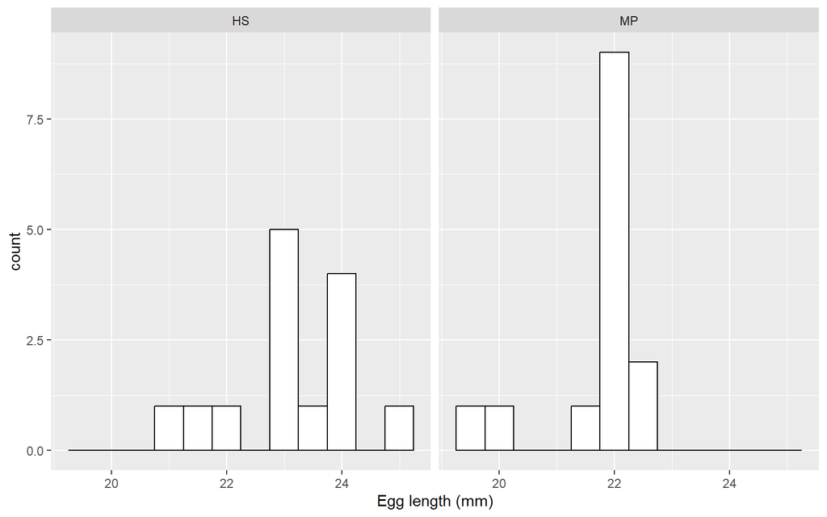

```r
ggplot(Cuckoos_2, aes(x = EggL)) +
  geom_histogram(binwidth=0.5, colour="black", fill="white") +
  facet_wrap(~Species, scales="fixed") +  #scales = const
  xlab("Egg length (mm)")
```

Wykonano **test normalności Shapiro-Wilka** na dwóch próbach danych, związanych z długością jaj w dwóch gatunkach kukułek. Test ten służy do sprawdzenia, czy próba danych pochodzi z rozkładu normalnego. W przypadku pierwszej próby (Species == “HS”), wartość p wynosi 0,5366, co oznacza, że brak jest wystarczających dowodów na odrzucenie hipotezy o normalności rozkładu. W przypadku drugiej próby (Species == “MP”), wartość p wynosi 0,0002377, co oznacza, że hipoteza o normalności rozkładu zostaje odrzucona na rzecz hipotezy alternatywnej, czyli że rozkład nie jest normalny.

Wykonano również **test F** dla porównania dwóch wariancji prób danych dotyczących długości jaj w dwóch różnych gatunkach kukułek.

Wartość p równa się 0,4055, co oznacza, że brak jest wystarczających dowodów na odrzucenie hipotezy o równości wariancji między tymi dwoma grupami. Oznacza to, że wariancje obu prób są porównywalne, a różnice w długości jaj między tymi dwoma gatunkami kukułek nie są znaczące statystycznie w kontekście wariancji.

Estymowana wartość proporcji wariancji między tymi dwoma grupami wynosi 1,604. Wartości proporcji wariancji większe niż 1 sugerują większą zmienność w jednej z grup. W tym przypadku, wartość proporcji jest nieznacznie większa niż 1, ale brak jest wystarczających dowodów na odrzucenie hipotezy o równości wariancji.

## Próbując otrzymać rozkład normalny decydujemy się na usunięcie wartości odstających.

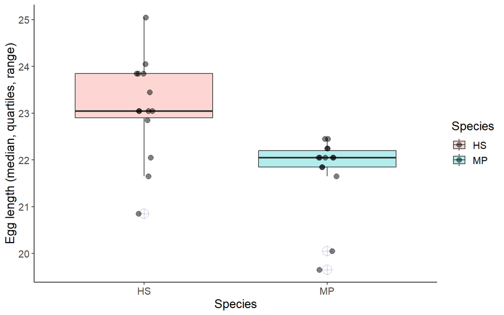

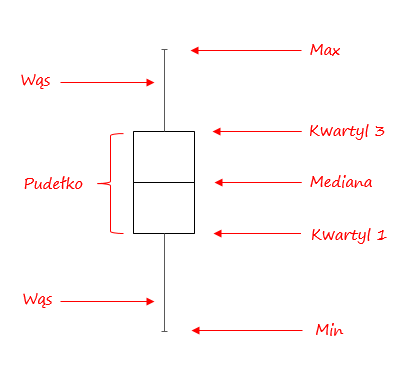

```r
#Sprawdzenie czy sa wartosci odstajace


ggplot(data = Cuckoos_2,
       mapping = aes(x = Species,
                     y = EggL,
                     fill = Species)) +
  geom_boxplot(
    alpha = 0.3,
    outlier.shape = 10,
    outlier.colour = "dark blue",
    outlier.size = 5
  ) + theme_classic() +
  geom_point(
    color = "black",
    position = position_jitterdodge(jitter.width = 0.1),
    size = 3,
    alpha = 0.5,
    stroke = 0
  ) +
  theme(text = element_text(size = 14)) +
  labs(x = "Species", y = "Egg length (median, quartiles, range)")
```

```r
#Usuwanie wartości odstajacych
Cuckoos_2_HS <- Cuckoos_2[Cuckoos_2$EggL > 21 & Cuckoos_2$Species == "HS",]
Cuckoos_2_MP <- Cuckoos_2[Cuckoos_2$EggL > 21 & Cuckoos_2$Species == "MP",]

Cuckoos_2_Filtered <- full_join(Cuckoos_2_HS,Cuckoos_2_MP)
shapiro.test(Cuckoos_2_HS$EggL)
```

```
##
##  Shapiro-Wilk normality test
##
## data:  Cuckoos_2_HS$EggL
## W = 0.95202, p-value = 0.6292
```

```r
shapiro.test(Cuckoos_2_MP$EggL)
```

```
##
##  Shapiro-Wilk normality test
##
## data:  Cuckoos_2_MP$EggL
## W = 0.92919, p-value = 0.3716
```

Teraz po odrzuceniu wartosci odstajacych otzymujemy rozklady normalne

```r
#2.3
t.test(data = Cuckoos_2_Filtered, EggL~Species, paired=FALSE, var.equal=TRUE)
```

```
##
##  Two Sample t-test
##
## data:  EggL by Species
## t = 4.6134, df = 23, p-value = 0.000122
## alternative hypothesis: true difference in means between group HS and group MP is not equal to 0
## 95 percent confidence interval:
##  0.6689872 1.7566538
## sample estimates:
## mean in group HS mean in group MP
##         23.29615         22.08333
```

```r
Cuckoo2_ANOVA <- aov(EggL~Species, data = Cuckoos_2_Filtered)
summary(Cuckoo2_ANOVA)
```

```
##             Df Sum Sq Mean Sq F value   Pr(>F)
## Species      1  9.179   9.179   21.28 0.000122 ***
## Residuals   23  9.919   0.431
## ---
## Signif. codes:  0 '***' 0.001 '**' 0.01 '*' 0.05 '.' 0.1 ' ' 1
```

Wartość p-value jest mniejsza od 0.05 więc odrzucamy hipotezę zerową i przyjmujemy alternatywną.

W przedstawionym wyniku, t-statystyka wynosi 4.6134, co jest stosunkowo dużą wartością w porównaniu do rozrzutu danych, a p-value wynosi 0.000122, co oznacza, że istnieje bardzo małe prawdopodobieństwo, że różnica między średnimi wynika z przypadku. 95% przedział ufności wskazuje, że średnia długość jaj HS jest większa niż średnia długość jaj MP, co potwierdza wnioski z testu t.

Pr(>F) w wyniku ANOVA oznacza p-value. Również tu p-value jest mniejsza niż poziom istotności, hipoteza zerowa zostaje odrzucona i można stwierdzić, że istnieje statystycznie istotna różnica między średnimi wartościami długości jaj między dwoma gatunkami kukułek.

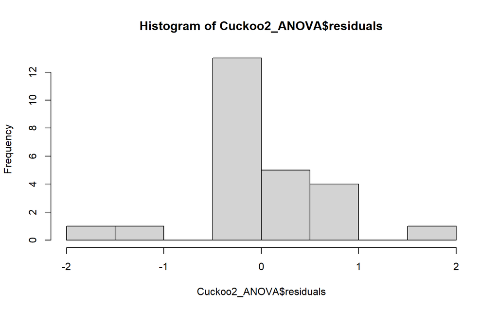

```r
#2.4
hist(Cuckoo2_ANOVA$residuals)
```

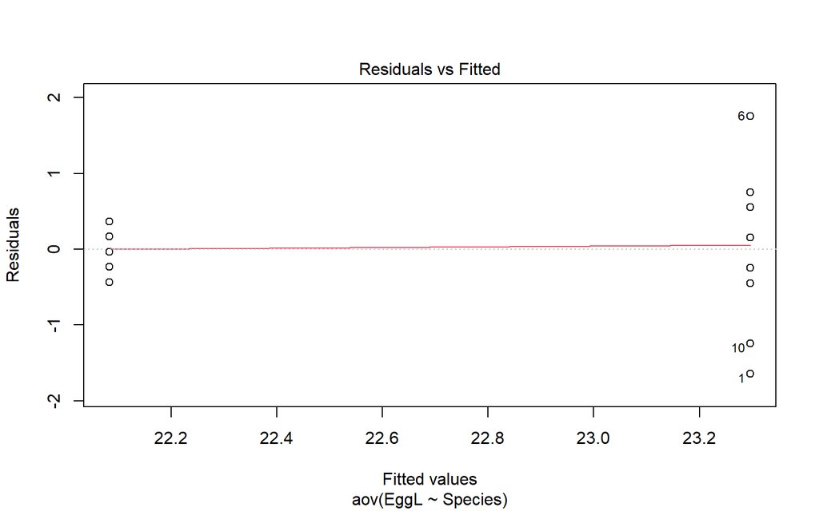

```r
plot(Cuckoo2_ANOVA,1)
```

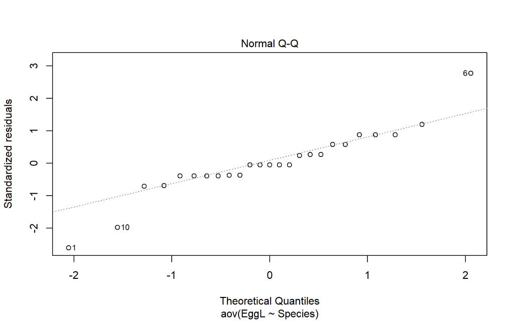

```r
plot(Cuckoo2_ANOVA,2)
```

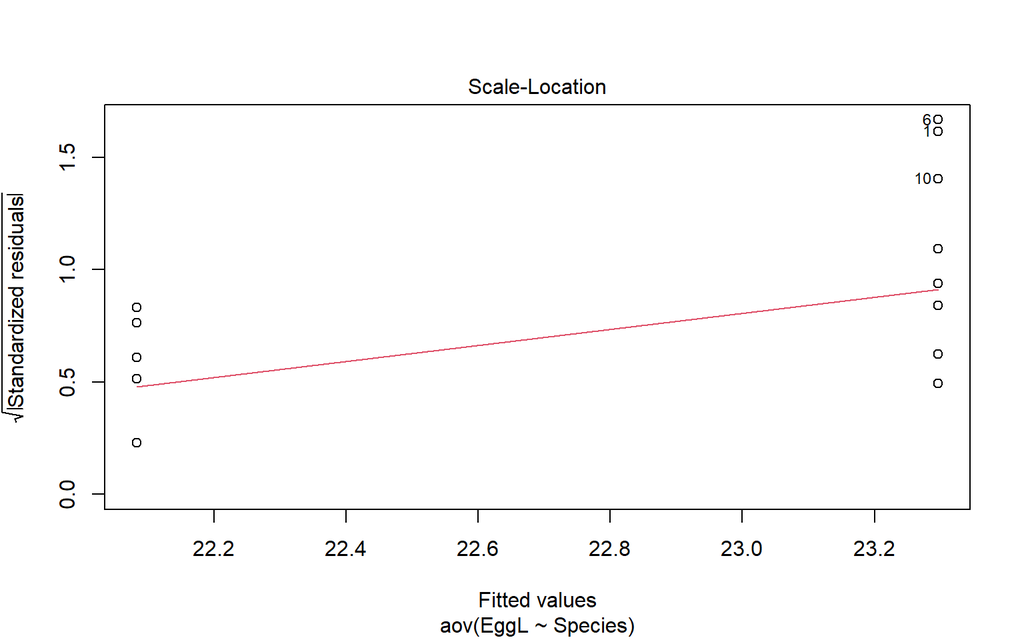

```r
plot(Cuckoo2_ANOVA,3)
```

Wykres odbiega od rozkładu normalnego lecz jest to bardzo dokładny test.

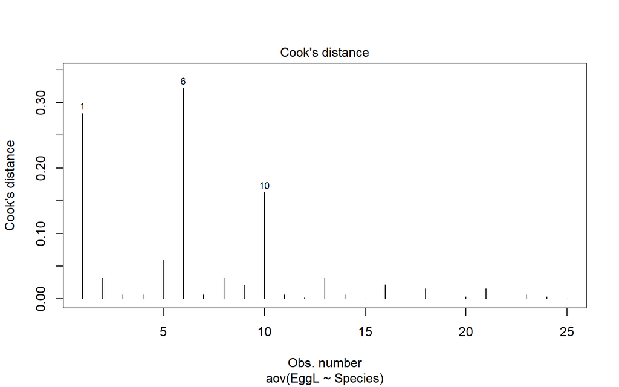

```r
plot(Cuckoo2_ANOVA,4)
```

Wykres pokazuje jaki konkretnie wpływ maja dane wartości na oszacowanie. Idealnie jest gdy każda wartość ma taki sam wpływ, aczkolwiek u nas nie odbiegają one bardzo.

Uwaga: to zadanie wygląda jak dublowanie punktu 2.2., ale właśnie o to chodzi, żeby pokazać te alternatywne sposoby badania rozkładów. W ANOVA (i modelach liniowych w ogóle) założenia dotyczą naprawdę rozkładu wartości resztowych, a NIE rozkładu bezpośrednio obserwowanych wartości, więc żeby sprawdzić czy założenia ANOVA są spełnione, to trzeba taką analizę najpierw wykonać – a w razie potrzeby wykonać ponownie po odpowiednim zmodyfikowaniu danych. W przypadku bardziej skomplikowanych modeli ANOVA, a zwłaszcza modeli ANCOVA, badanie rozkładu bezpośrednio obserwowanych wartości, takiej jak wykonywane przed testem t Studenta dla porównania dwóch grup, nie może już być zastosowane, bo nie da adekwatnej odpowiedzi.

2.5) Dodaj adekwatne wykresy ilustrujące najważniejsze wyniki, używając zarówno wykresów ogólnego stosowania, jak i wykresów powiązanych wprost z wynikami funkcji aov().

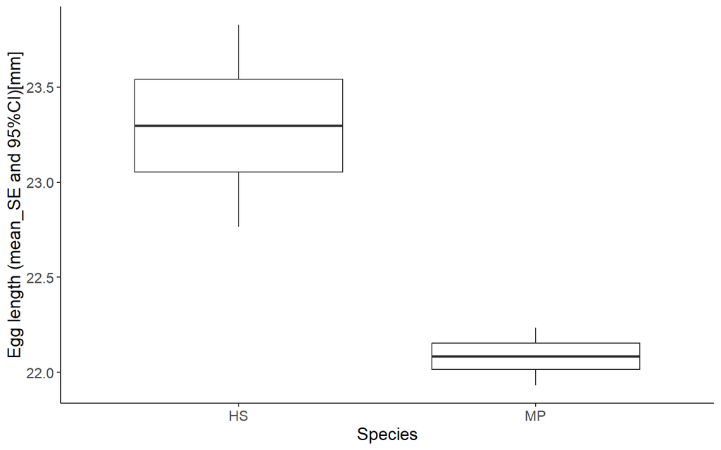

```r
#2.5
Mean_SE_95CI <- function(Y) {
  v <- c(mean(Y)-qt(0.975, df = length(Y)-1) * sd(Y) / sqrt(length(Y)),
         mean(Y) - sd(Y)/sqrt(length(Y)),
         mean(Y),
         mean(Y) + sd(Y)/sqrt(length(Y)),
         mean(Y)+qt(0.975, df = length(Y)-1) * sd(Y) / sqrt(length(Y)))
  names(v) <- c("ymin", "lower", "middle", "upper", "ymax")
  v
}

ggplot(data = Cuckoo2_ANOVA, mapping = aes(x = Species,
                                         y = EggL)) +
  stat_summary(fun.data=Mean_SE_95CI, geom="boxplot", width=0.7) +
  theme_classic() + theme(text = element_text(size = 14)) +
  labs(x = "Species", y = "Egg length (mean_SE and 95%CI)[mm]")
```

2.6) Przedstaw i uzasadnij wnioski z wykonanej analizy, odnoszące się do stawianej hipotezy roboczej.

Dokonana analiza z wykorzystaniem testu t-studenta oraz ANOVA pozwala na odrzucenie hipotezy zerowej i przyjęcie alternatywnej. Średnia długość jaj kukułki w gniazdach świergotka łąkowego i w gniazdach płochacza pokrzywnica różni się.

# Zadanie 2

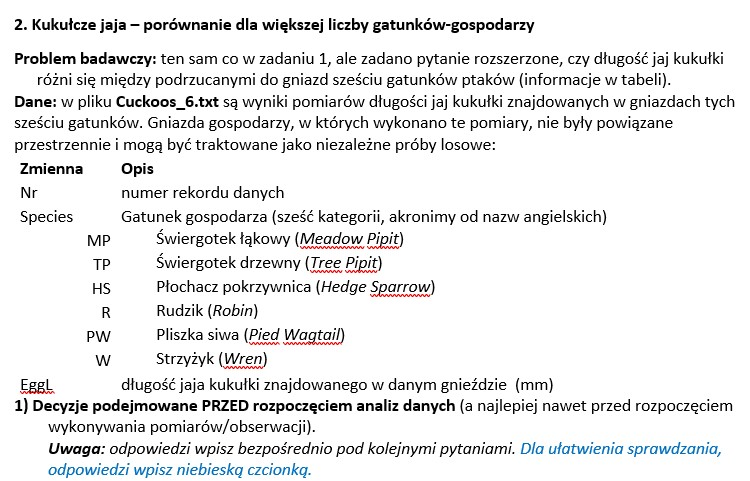

1.1) Sformułuj adekwatną do problem badawczego i dostępnych danych hipotezę roboczą. Spróbuj przedstawić dwie wersje – jedną odnoszącą się do różnic między średnimi, a drugą do działania „czynnika”.  
Średnia długość jaj kukułki w gniazdach sześciu gatunków ptaków różni się.

1.2) Sformułuj adekwatną hipotezę zerową.  
Średnia długość jaj kukułki w gniazdach sześciu gatunków ptaków jest taka sama.

1.3) Sformułuj adekwatną hipotezę alternatywną.  
Średnia długość jaj kukułki w gniazdach sześciu gatunków ptaków różni się.

1.4) Jakiego testu użyjesz „z wyboru” do testowania hipotezy zerowej? Testu ANOVA dla wielu grup

1.5. Jakie założenia teoretycznie dotyczące rozkładu są wymagane dla wybranego testu?

- rozkład powinien być zbliżony do rozkładu normalnego
- próby niezależne
- równe wariancje

```r
Cuckoos_6 <- read.table("Cuckoos_6.txt", header = TRUE, sep = "\t")
Cuckoos_6
```

```
##    Nr Species  EggL
## 1   1      HS 21.65
## 2   2      HS 23.85
## 3   3      HS 23.05
## 4   4      HS 23.05
## 5   5      HS 24.05
## 6   6      HS 25.05
## 7   7      HS 23.05
## 8   8      HS 23.85
## 9   9      HS 22.85
## 10 10      HS 22.05
## 11 11      HS 20.85
## 12 12      HS 23.05
## 13 13      HS 23.45
## 14 14      HS 23.85
```

[output cut: 70 more lines]

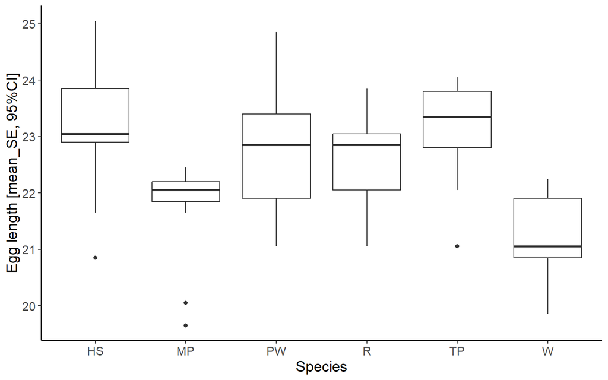

```r
#2.1
ggplot(data = Cuckoos_6, mapping = aes(x = Species,
                                       y = EggL)) +
  geom_boxplot() + theme_classic() +
  theme_classic() + theme(text = element_text(size = 14)) +
  labs(x = "Species", y = "Egg length [mean_SE, 95%CI]")
```

```r
Cuckoos_6 %>% group_by(Species) %>%
  summarise(mean=mean(EggL), median=median(EggL),
            maximum=max(EggL), minimum=min(EggL),
            sd=sd(EggL), N=length(EggL))
```

```
## # A tibble: 6 × 7
##   Species  mean median maximum minimum    sd     N
##   <chr>   <dbl>  <dbl>   <dbl>   <dbl> <dbl> <int>
## 1 HS       23.1   23.0    25.0    20.8 1.07     14
## 2 MP       21.8   22.0    22.4    19.6 0.844    14
## 3 PW       22.8   22.8    24.8    21.0 1.06     14
## 4 R        22.6   22.8    23.8    21.0 0.728    14
## 5 TP       23.2   23.4    24.0    21.0 0.865    14
## 6 W        21.1   21.0    22.2    19.8 0.771    14
```

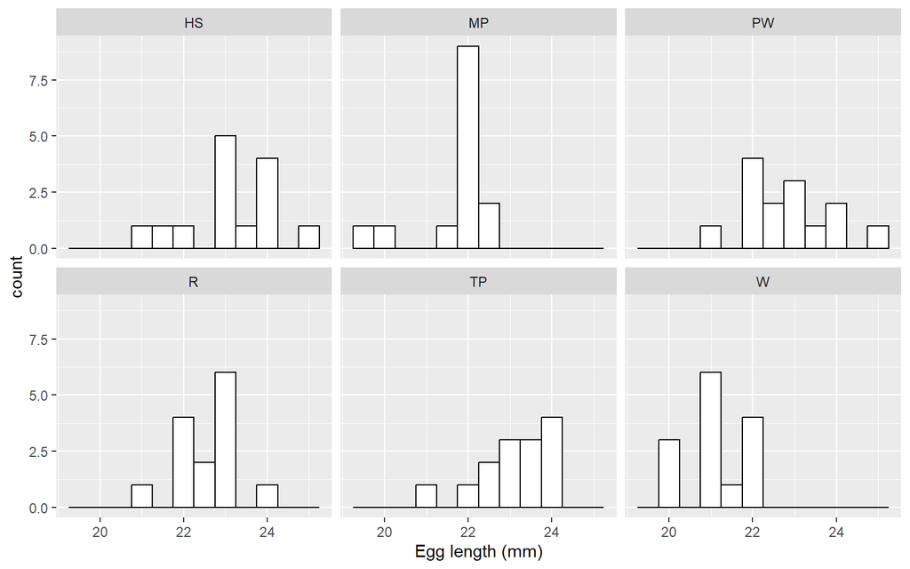

```r
#2.3
ggplot(Cuckoos_6, aes(x = EggL)) +
  geom_histogram(binwidth=0.5, colour="black", fill="white") +
  facet_wrap(~Species, scales="fixed") +  #  dzieli histogram na osobne panele w zależności od wartości zmiennej Species
  xlab("Egg length (mm)")
```

Aby dokonać analizy rozkładu wartości resztowych wykonujemy test ANOVA

```r
Cuckoo6_ANOVA <- aov(EggL~Species, data = Cuckoos_6)
summary(Cuckoo6_ANOVA)
```

```
##             Df Sum Sq Mean Sq F value   Pr(>F)
## Species      5  46.77   9.355   11.58 2.22e-08 ***
## Residuals   78  63.01   0.808
## ---
## Signif. codes:  0 '***' 0.001 '**' 0.01 '*' 0.05 '.' 0.1 ' ' 1
```

Wartość p-value jest mniejsza od 0.05 co daje nam argument do odrzucenia hipotezy zerowej i przyjęcia alternatywnej.

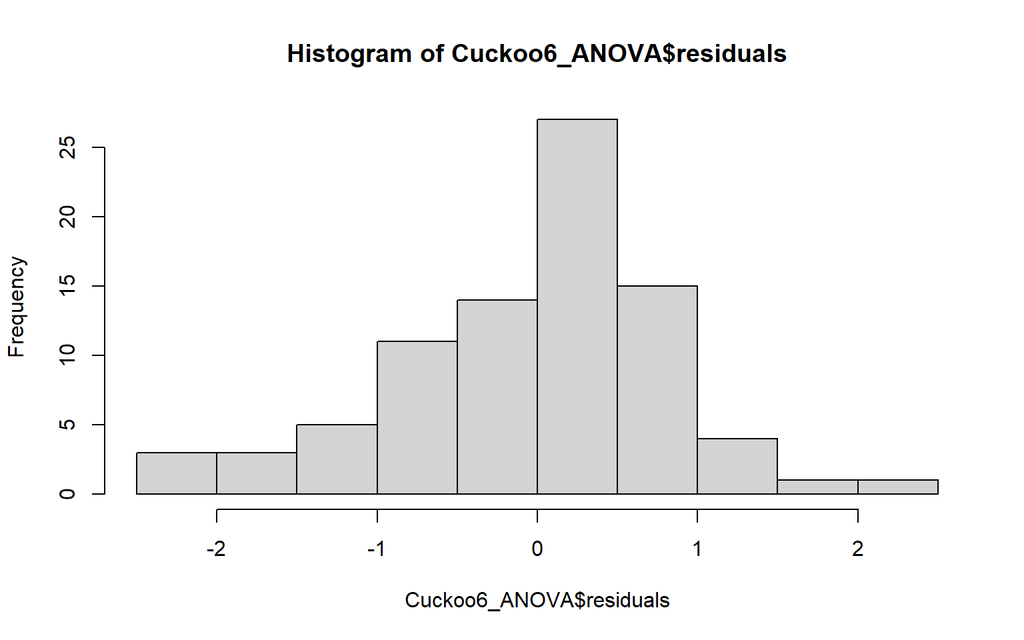

```r
hist(Cuckoo6_ANOVA$residuals)
```

Rozkład wartości resztowych jest zbliżony do rozkładu normalnego, zatem można przyjąć że również rozkład dla każdej z grup jest zbliżony do normalnego.

```r
TukeyHSD(Cuckoo6_ANOVA, header = TRUE, sep = "\t")
```

```
##   Tukey multiple comparisons of means
##     95% family-wise confidence level
##
## Fit: aov(formula = EggL ~ Species, data = Cuckoos_6)
##
## $Species
##              diff         lwr        upr     p adj
## MP-HS -1.35714286 -2.34972876 -0.3645570 0.0019587
## PW-HS -0.30000000 -1.29258590  0.6925859 0.9494888
## R-HS  -0.51428571 -1.50687161  0.4783002 0.6565029
## TP-HS  0.05714286 -0.93544304  1.0497288 0.9999806
## W-HS  -1.98571429 -2.97830019 -0.9931284 0.0000016
## PW-MP  1.05714286  0.06455696  2.0497288 0.0300804
## R-MP   0.84285714 -0.14972876  1.8354430 0.1424774
## TP-MP  1.41428571  0.42169981  2.4068716 0.0010978
## W-MP  -0.62857143 -1.62115733  0.3640145 0.4403256
## R-PW  -0.21428571 -1.20687161  0.7783002 0.9883657
## TP-PW  0.35714286 -0.63544304  1.3497288 0.8987772
## W-PW  -1.68571429 -2.67830019 -0.6931284 0.0000575
## TP-R   0.57142857 -0.42115733  1.5640145 0.5476349
## W-R   -1.47142857 -2.46401447 -0.4788427 0.0006056
## W-TP  -2.04285714 -3.03544304 -1.0502712 0.0000008
```

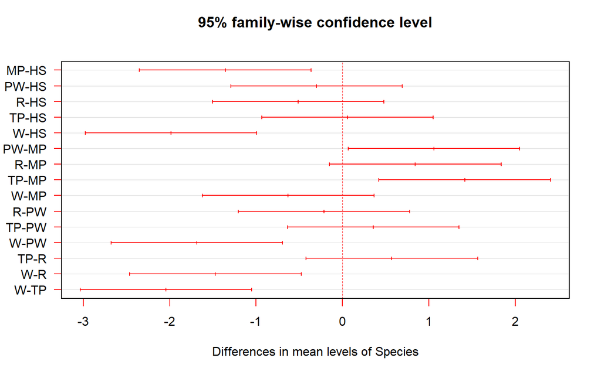

```r
plot(TukeyHSD(Cuckoo6_ANOVA), las=1, col="red")
```

Różnice istotne statystycznie występują pomiędzy grupami które odstają od wartości środkowej.

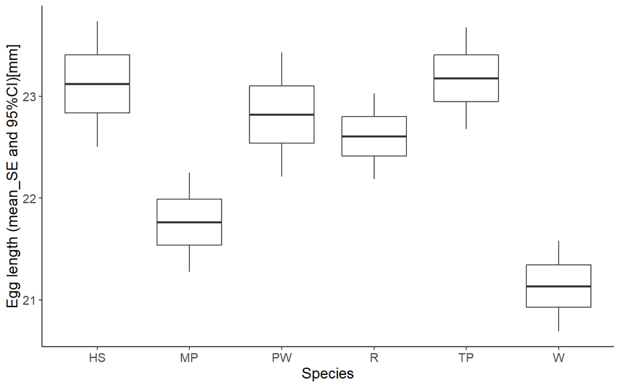

```r
#2.4
ggplot(data = Cuckoo6_ANOVA, mapping = aes(x = Species,
                                         y = EggL)) +
  stat_summary(fun.data=Mean_SE_95CI, geom="boxplot", width=0.7) +
  theme_classic() + theme(text = element_text(size = 14)) +
  labs(x = "Species", y = "Egg length (mean_SE and 95%CI)[mm]")
```

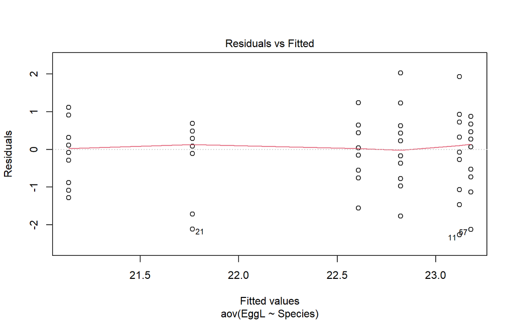

```r
plot(Cuckoo6_ANOVA, 1)
```

Patrząc na wykres możemy stwierdzić że wariancje między grupami są podobne.

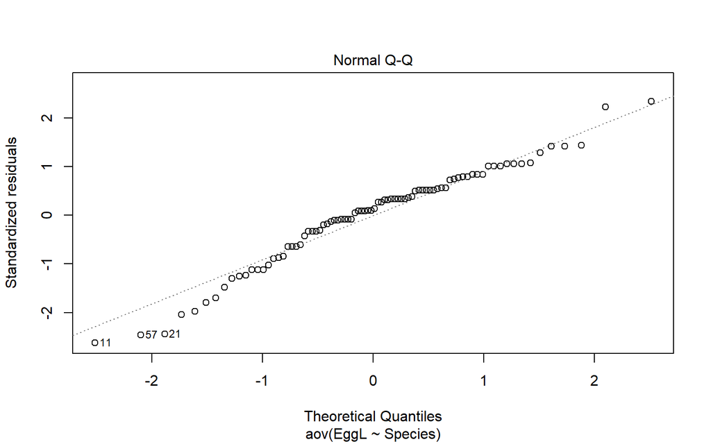

```r
plot(Cuckoo6_ANOVA, 2)
```

Widzimy że rozkład wartości resztowych jest zbliżony do rozkładu normalnego.

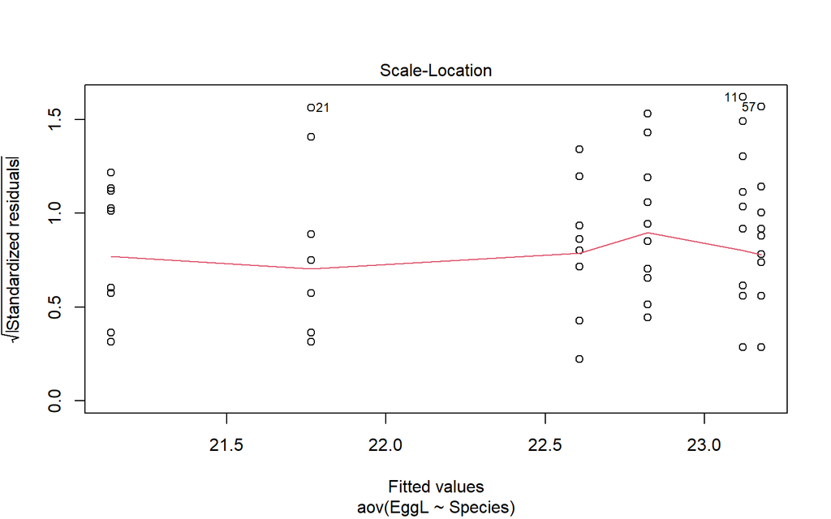

```r
plot(Cuckoo6_ANOVA, 3)
```

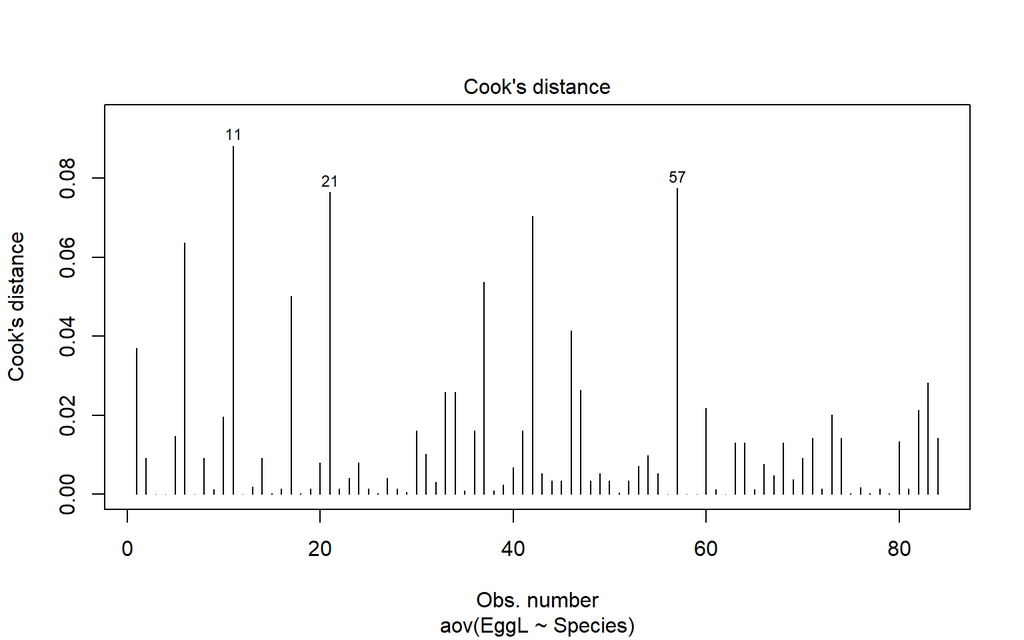

```r
#Miara wielkości wpływu pojedynczej obserwacji na wyniki:
plot(Cuckoo6_ANOVA, 4)
```

```r
#2.5
kruskal.test(EggL~Species, data=Cuckoos_6)
```

```
##
##  Kruskal-Wallis rank sum test
##
## data:  EggL by Species
## Kruskal-Wallis chi-squared = 35.205, df = 5, p-value = 1.37e-06
```

Stopnie swobody (df) wynoszą 5, co odpowiada liczbie gatunków minus 1. Wartość p wynosi 1,37e-06, czyli mniej niż 0,05, co wskazuje na mocne dowody przeciwko hipotezie zerowej, że wszystkie gatunki mają tę samą średnią długość jaj. Dlatego możemy stwierdzić, że istnieją znaczne różnice w długości jaj między co najmniej dwoma z sześciu gatunków.

Po wykonanej analizie z użyciem testu ANOVA i Kruskala-Wallisa otrzymujemy argumentu za odrzuceniem hipotezy zerowej i przyjęciem alternatywnej. Średnia długość jaj kukułki w gniazdach świergotka łąkowego i w gniazdach płochacza pokrzywnica różni się.

# Zadanie 3

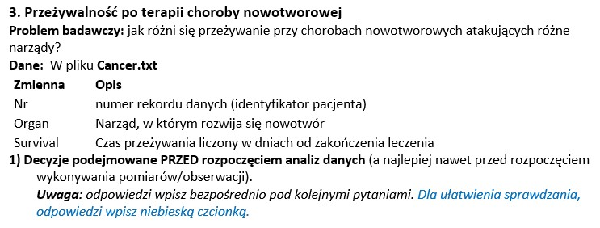

1.1) Sformułuj adekwatną do problem badawczego i dostępnych danych hipotezę roboczą. Spróbuj przedstawić dwie wersje – jedną odnoszącą się do różnic między średnimi, a drugą do działania „czynnika”.

Przeżywalność przy chorobach nowotworowych atakujących różne narządy różni się.

1.2) Sformułuj adekwatną hipotezę zerową. Przeżywalność przy chorobach nowotworowych atakujących różne narządy jest taka sama.

1.3) Sformułuj adekwatną hipotezę alternatywną. Przeżywalność przy chorobach nowotworowych atakujących różne narządy różni się.

1.4) Jakiego testu użyjesz „z wyboru” do testowania hipotezy zerowej?  
Testu ANOVA

1.5. Jakie założenia teoretycznie dotyczące rozkładu są wymagane dla wybranego testu?

- rozkład zbliżony do rozkładu normalnego
- próby niezależne
- równe wariancje

```r
Cancer <- read.table("Cancer.txt", header = TRUE, sep = "\t")
Cancer
```

```
##    Nr    Organ Survival
## 1   1  Stomach      124
## 2   2  Stomach       42
## 3   3  Stomach       25
## 4   4  Stomach       45
## 5   5  Stomach      412
## 6   6  Stomach       51
## 7   7  Stomach     1112
## 8   8  Stomach       46
## 9   9  Stomach      103
## 10 10  Stomach      876
## 11 11  Stomach      146
## 12 12  Stomach      340
## 13 13  Stomach      396
## 14 14 Bronchus       81
```

[output cut: 50 more lines]

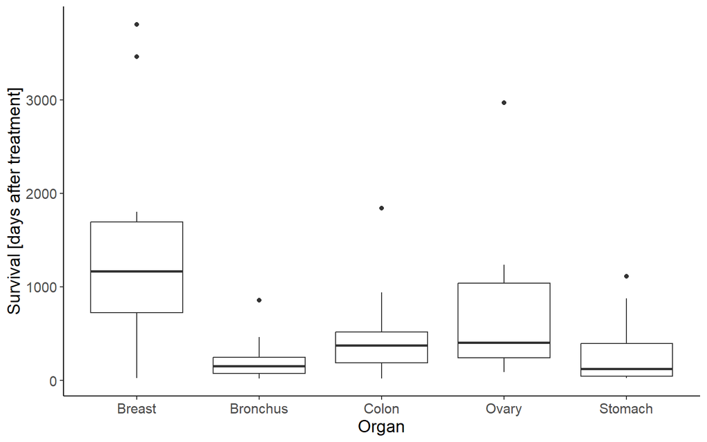

```r
#2.1
ggplot(data = Cancer, mapping = aes(x = Organ,
                                       y = Survival)) +
  geom_boxplot() + theme_classic() +
  theme_classic() + theme(text = element_text(size = 14)) +
  labs(x = "Organ", y = "Survival [days after treatment]")
```

```r
Cancer %>% group_by(Organ) %>%
  summarise(mean=mean(Survival), median=median(Survival),
            maximum=max(Survival), minimum=min(Survival),
            sd=sd(Survival), N=length(Survival))
```

```
## # A tibble: 5 × 7
##   Organ     mean median maximum minimum    sd     N
##   <chr>    <dbl>  <dbl>   <int>   <int> <dbl> <int>
## 1 Breast   1396.   1166    3808      24 1239.    11
## 2 Bronchus  212.    155     859      20  210.    17
## 3 Colon     457.    372    1843      20  427.    17
## 4 Ovary     884.    406    2970      89 1099.     6
## 5 Stomach   286     124    1112      25  346.    13
```

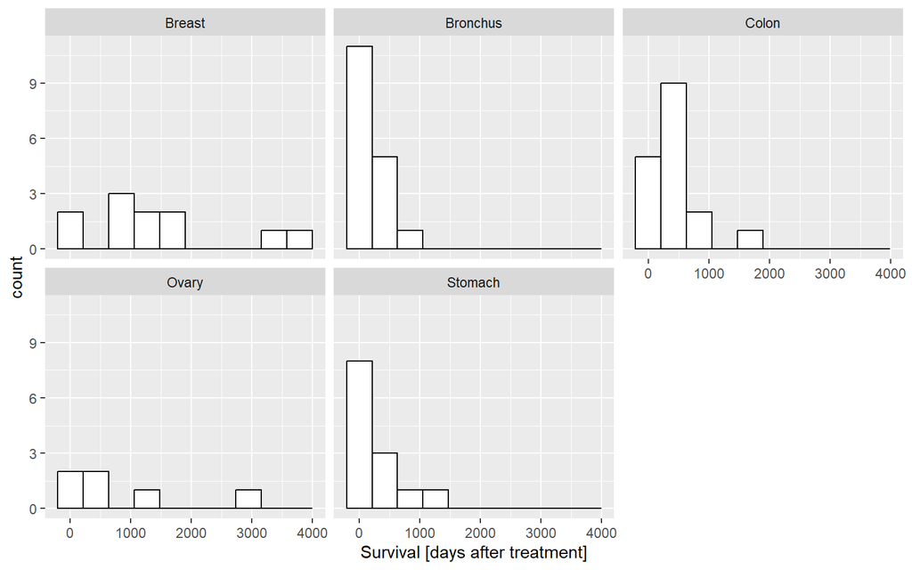

```r
#2.2
ggplot(Cancer, aes(x = Survival)) +
  geom_histogram(bins=10, colour="black", fill="white") +
  facet_wrap(~Organ, scales="fixed") +
  xlab("Survival [days after treatment]")
```

Wykresy odbiegają od rozkładu normalnego.

```r
Cancer_ANOVA <- aov(Survival~Organ, data = Cancer)
summary(Cancer_ANOVA)
```

```
##             Df   Sum Sq Mean Sq F value   Pr(>F)
## Organ        4 11535761 2883940   6.433 0.000229 ***
## Residuals   59 26448144  448274
## ---
## Signif. codes:  0 '***' 0.001 '**' 0.01 '*' 0.05 '.' 0.1 ' ' 1
```

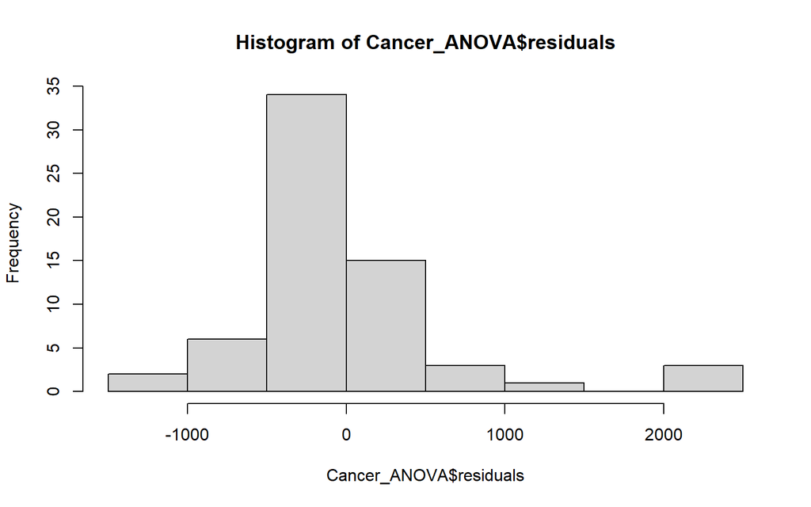

```r
hist(Cancer_ANOVA$residuals)
```

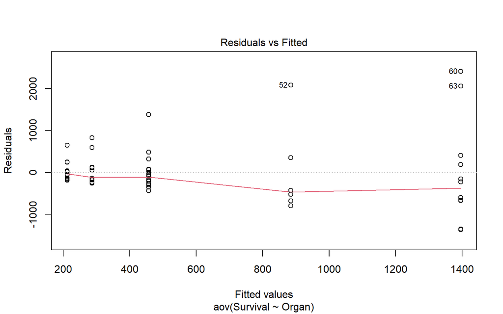

```r
plot(Cancer_ANOVA, 1)
```

Wariancje różnią się pomiędzy grupami.

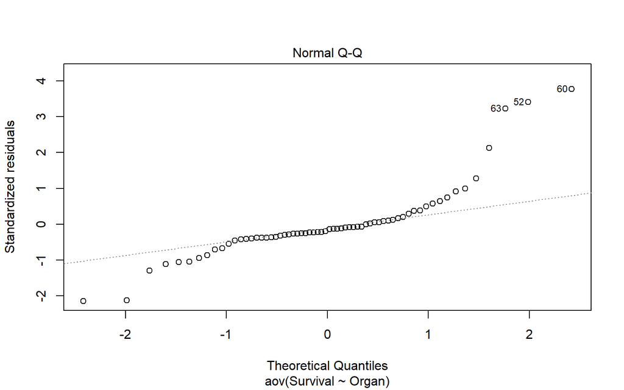

```r
plot(Cancer_ANOVA, 2)
```

Rozkład znacząco odbiega od rozkładu normalnego.

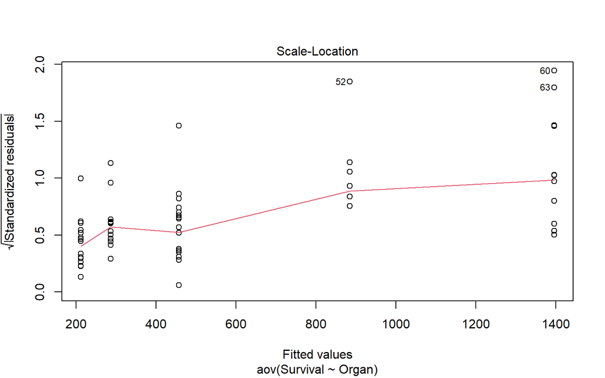

```r
plot(Cancer_ANOVA, 3)
```

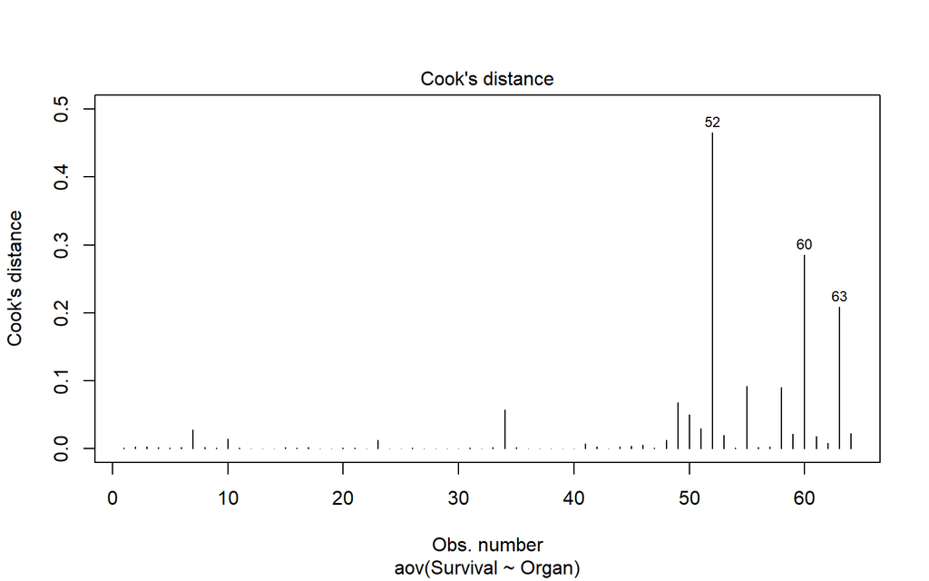

```r
plot(Cancer_ANOVA, 4)
```

Wartości odstające nie mają wielkiego wpływu na wyniki, gdyż są mniejsze od 1.